# DS 202 Lab 4

John Banta & Kelsey McInturff

10/17/2019

Owner username: jdbanta

Partner username: kmcintur

Link to repo: https://github.com/jdbanta/ds202_lab4

# Dataset: 2018 Cyclone Football Data

This lab works with an excerpt of the individual player data of the Cyclone football team.

```r
library(readxl)
defense <- read_excel('cyclonesFootball2018.xlsx', sheet='Defensive')
str(defense)
```

```
## Classes 'tbl_df', 'tbl' and 'data.frame':    446 obs. of  11 variables:
##  $ Name             : chr  "Eisworth, Greg" "Eisworth, Greg" "Eisworth, Greg" "Eisworth, Greg" ...
##  $ Opponent_Opponent: chr  "Iowa" "Oklahoma" "Akron" "TCU" ...
##  $ Tackles_Solo     : chr  "3" "6" "7" "6" ...
##  $ Tackles_ASST     : chr  "3" "8" "2" "3" ...
##  $ Tackles_TFL      : chr  "0" "1.0" "1.0" "0" ...
##  $ Tackles_Sack     : chr  "0" "0" "0" "0" ...
##  $ Turnover_FF      : chr  "0" "1" "0" "0" ...
##  $ Turnover_FR      : chr  "0" "0" "0" "0" ...
##  $ Turnover_INT     : chr  "0" "0" "0" "0" ...
##  $ Pass_QBH         : chr  "0" "0" "0" "0" ...
##  $ Pass_PB          : chr  "0" "0" "3" "0" ...
```

```r
offense <- read_excel('cyclonesFootball2018.xlsx', sheet='Offensive')
bio <- read_excel('cyclonesFootball2018.xlsx', sheet='Biography')
```

## Cleaning

# 1.

```r
library(dplyr)
library(tidyr)
offense$Name<-as.factor(offense$Name)
offense$Opponent_Opponent<-as.factor(offense$Opponent_Opponent)
defense$Opponent_Opponent<-as.factor(defense$Opponent_Opponent)
defense$Name<-as.factor(defense$Name)
```

# 2.

```r
bio$Weight<-as.numeric(bio$Weight)
colo<-c("Receiving_REC","Receiving_YDS","Receiving_TD","Rushing_ATT","Rushing_YDS","Rushing_TD","Passing_CMP-ATT","Passing_YDS","Passing_TD","Passing_INT")
offense[colo]<-sapply(offense[colo], as.numeric)
cold<-c("Tackles_Solo","Tackles_ASST","Tackles_TFL","Tackles_Sack","Turnover_FF","Turnover_FR","Turnover_INT","Pass_QBH","Pass_PB")
defense[cold]<-sapply(defense[cold],as.numeric)
```

# 3.

```r
bio<-separate(data=bio,col=Height,into=c("Feet","inc"),sep="\\-")
bio$Feet<-as.numeric(bio$Feet)
bio$inc<-as.numeric(bio$inc)
bio$height_in_inches<-(bio$Feet*12+bio$inc)
head(bio)
```

```
## # A tibble: 6 x 9
##   Name  Position  Feet   inc Weight Class Hometown Highschool
##   <chr> <chr>    <dbl> <dbl>  <dbl> <chr> <chr>    <chr>
## 1 Aker~ Wide Re~     6     0    192 Reds~ Cedar R~ Washington
## 2 Alle~ Tight E~     6     7    240 Reds~ Nixa, M~ Nixa
## 3 Alt,~ Offensi~     6     2    290 Reds~ Cedar R~ Washington
## 4 Ande~ Tight E~     6     4    250 Reds~ League ~ Clear Fal~
## 5 Assa~ Placeki~     6     0    191 Reds~ Napervi~ Central
## 6 Aust~ Linebac~     5    11    205 Reds~ Walnut,~ Bishop Am~
## # ... with 1 more variable: height_in_inches <dbl>
```

```r
colb<-c("Name","Position","Class","Hometown","Highschool")
bio[colb]<-lapply(bio[colb],factor)

bioClean<-select(bio,-c("Feet","inc"))
head(bioClean)
```

```
## # A tibble: 6 x 7
##   Name     Position   Weight Class   Hometown   Highschool height_in_inches
##   <fct>    <fct>       <dbl> <fct>   <fct>      <fct>                 <dbl>
## 1 Akers, ~ Wide Rece~    192 Redshi~ Cedar Rap~ Washington               72
## 2 Allen, ~ Tight End     240 Redshi~ Nixa, Mo.  Nixa                     79
## 3 Alt, Ge~ Offensive~    290 Redshi~ Cedar Rap~ Washington               74
## 4 Anderso~ Tight End     250 Redshi~ League Ci~ Clear Fal~               76
## 5 Assalle~ Placekick~    191 Redshi~ Napervill~ Central                  72
## 6 Austin,~ Linebacker    205 Redshi~ Walnut, C~ Bishop Am~               71
```

```r
defClean<-defense

offClean<-offense
```

# 4.

```r
sapply(offClean,class)
```

```
##              Name Opponent_Opponent     Receiving_REC     Receiving_YDS
##          "factor"          "factor"         "numeric"         "numeric"
##      Receiving_TD       Rushing_ATT       Rushing_YDS        Rushing_TD
##         "numeric"         "numeric"         "numeric"         "numeric"
##   Passing_CMP-ATT       Passing_YDS        Passing_TD       Passing_INT
##         "numeric"         "numeric"         "numeric"         "numeric"
```

```r
sapply(defClean,class)
```

```
##              Name Opponent_Opponent      Tackles_Solo      Tackles_ASST
##          "factor"          "factor"         "numeric"         "numeric"
##       Tackles_TFL      Tackles_Sack       Turnover_FF       Turnover_FR
##         "numeric"         "numeric"         "numeric"         "numeric"
##      Turnover_INT          Pass_QBH           Pass_PB
##         "numeric"         "numeric"         "numeric"
```

```r
sapply(bioClean,class)
```

```
##             Name         Position           Weight            Class
##         "factor"         "factor"        "numeric"         "factor"
##         Hometown       Highschool height_in_inches
##         "factor"         "factor"        "numeric"
```

## Tidying Part A

# 1.

```r
defCleanGather = gather(defClean,key="Statistic", value="Value", 3:11)
```

# 2.

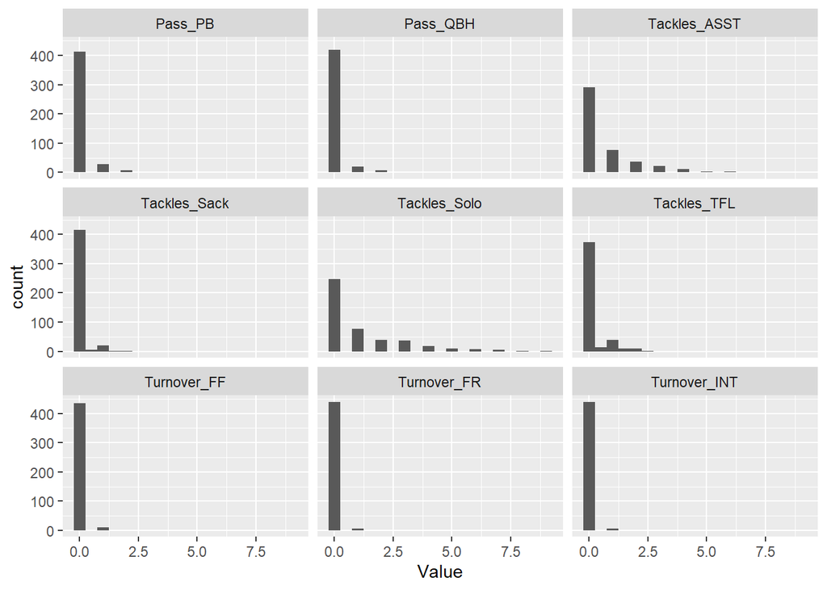

The turnover skills (Turnover_FF, Turnover_FR, and Turnover_INT) are the rarest defensive skills since almost all of the values are near 0 and only a few values are near 1.

# 3.

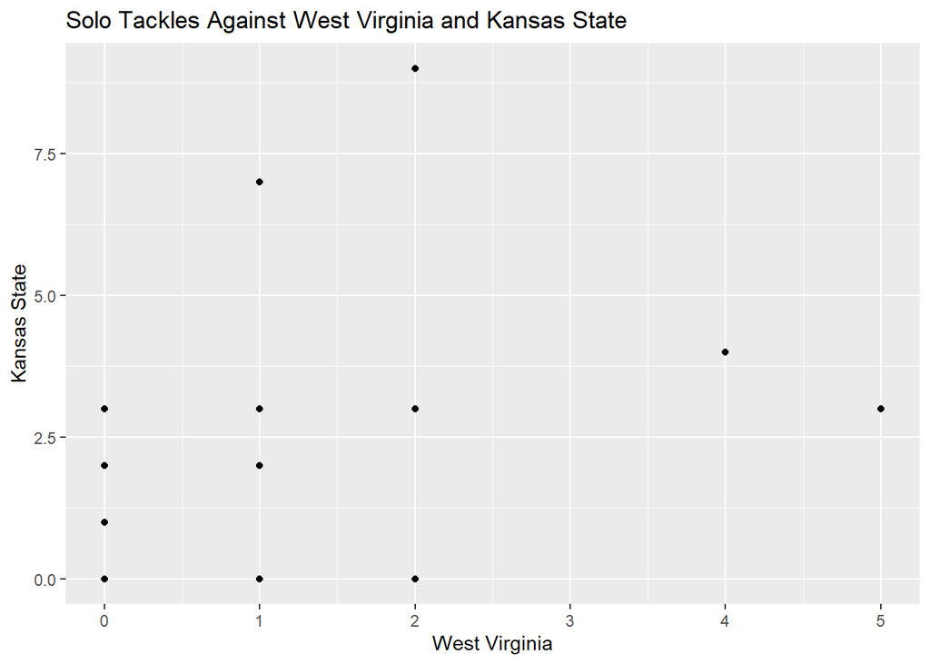

ISU had a better defense agaisnt Kansas State, since there were more defensive tackles agaisnt Kansas State than they did against West Virginia.

## Tidying Part B

# 1.

```r
bioCleanSeparate <- separate(bioClean, Hometown, into = c("City","State"), sep = ",")
```

# 2.

## Joining data frames

# 1.

```r
offbio<-inner_join(offClean,bioClean,by="Name")
colnames(offbio)
```

```
##  [1] "Name"              "Opponent_Opponent" "Receiving_REC"
##  [4] "Receiving_YDS"     "Receiving_TD"      "Rushing_ATT"
##  [7] "Rushing_YDS"       "Rushing_TD"        "Passing_CMP-ATT"
## [10] "Passing_YDS"       "Passing_TD"        "Passing_INT"
## [13] "Position"          "Weight"            "Class"
## [16] "Hometown"          "Highschool"        "height_in_inches"
```

# 2.

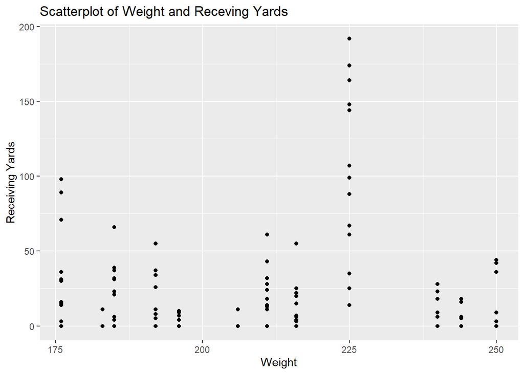

It appears that the players that weigh 225 pounds have the most receiving yards. However, with the removal of 15 rows because of missing values includes the linemen who only block and don’t run routes.

# 3.

Did a lot of receiving touchdowns from the Iowa State football team come from players that were from Iowa?

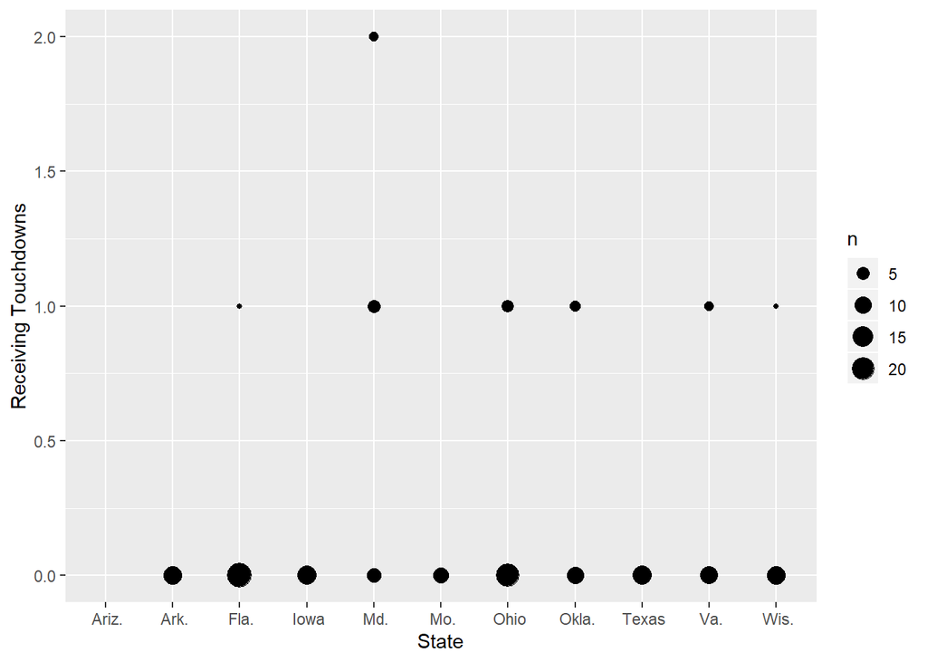

It looks like most of the receivers had no touchdowns, but it looks like there were multiple states with at least one player with at least one touchdown with the State of Maryland giving the most touchdowns. It also looks like the State of Iowa contributed no receiving touchdowns to the Iowa State football team in 2018.